# Neural Representations of Popularity and Leadership Status: RSA

Ovidia Stanoi

1/30/2026

This script includes 3 regression models that estimate, at the dyad level, how similarly two individuals are represented in the 9 ROIs of interest (valuation: vmPFC, amygdala, striatum, social cognition: dmPFC, rTPJ, lTPJ, relational binding: rHPC, lHPC, EC) as a function of how different their popularity and leadership statuses are. The first regression model (model 1) includes an **interaction term between the popularity and leadership status differences** to explore how the relationship between the difference in leadership status and neural dissimilarity in different ROIs might be moderated by difference in popularity status and vice-versa. The next two models include **only the main effects** of **popularity status differences** (model 2) or **leadership status differences** (model 3). Comparing these models allows us to explore what ROIs represent popularity and leadership status information together or independently. To account for multiple comparisons, all models are run in a multilevel framework with random slopes per ROI, nested within brain systems. We also included random intercepts for perceiver, targets, and dyads, nested within groups, as well as a number of control variables: whether or not the members of the dyad are the same gender, differences in attractiveness ratings provided by 6 independent raters, college year, household income, and parents’ education. We are also holding constant the perceivers’ characteristics: their own popularity and leadership status, attractiveness, gender, college year, hh income, and parents’ education. Additionally, in this model, we control for differences in the perceivers’ individual liking and leadership ratings of the target faces.

Clear global environment.

```r
remove(list=ls())
```

Open packages.

```r
library("tidyverse")
library("corrplot")
library("reshape")
library("rstanarm")
library("bmlm")
library("bayestestR")
library("flextable")
library("officer")
library("brms")
library("tidybayes")
```

Set up ggplot theme.

```r
theme_set(theme_bw() +
            theme(plot.title = element_text(size=14, hjust = .5),
                  axis.text=element_text(size=12),
                  axis.title=element_text(size=13),
                  strip.text = element_text(size=12),
                  # plot.title = element_text(size=20, hjust = .5), # use this for .pdf version of figures instead of .html
                  # axis.text=element_text(size=20),  # use this for .pdf version of figures instead of .html
                  # axis.title=element_text(size=22), # use this for .pdf version of figures instead of .html
                  # strip.text = element_text(size=18), # use this for .pdf version of figures instead of .html
                  axis.line = element_line(colour = "gray"),
                  panel.border = element_rect(colour = "gray"),
                  panel.grid.minor = element_blank(),
                  panel.background = element_rect(colour = "gray", linewidth = .8),
                  strip.background.x = element_rect(fill = "white", linetype = "solid",
                                          color = "gray", linewidth = .8),
                  legend.position = "none"))
```

Set up the file directory.

```r
path <- "~/Dropbox/Psychology_Projects/MURI Faces 2D"
```

Read the RSA dataset.

```r
d1 <- read.csv(sprintf("%s/Data/rsa_dataset.csv", path))
d2 <- read.csv(sprintf("%s/Data/rsa_dataset_individual_ratings.csv", path)) %>%
  dplyr::rename(like_diff_indepent_ratings_cw = like_diff_cw,
        leader_diff_indepent_ratings_cw = leader_diff_cw) %>%
  select(groupID, pID, dyad_name, roi, like_diff_indepent_ratings_cw, leader_diff_indepent_ratings_cw)
d <- left_join(d1, d2, by = c("groupID", "pID", "dyad_name", "roi"))
d$brain_system <- ifelse(d$roi %in% c("HO_amygdala", "Kable_VS", "vmPFC"), "valuation",
                         ifelse(d$roi %in% c("ERC", "r_HPC", "l_HPC"), "relational_binding",
                                ifelse(d$roi %in% c("Saxe_dmPFC", "l_TPJ", "r_TPJ"), "social_cognition", NA)))
```

Check the data format.

```r
head(d)
```

|  | groupID | pID | roi | face_1 | face_2 | dyad_name | neural_dissimilarity | like_diff_cb | like_diff_cw | leader_diff_cb | leader_diff_cw | attractive_diff_cb | attractive_diff_cw | like_avg_cw | like_avg_cb | leader_avg_cw | leader_avg_cb | attractive_avg_cw | attractive_avg_cb | gender_diff_cw | college_year_diff_cw | educ_parents_diff_cw | income_num_diff_cw | pID_like_strength_in | pID_leader_strength_in | pID_mean_attractive_rating | pID_gender | pID_college_year | pID_educ_parents | … |
| --- | --- | --- | --- | --- | --- | --- | --- | --- | --- | --- | --- | --- | --- | --- | --- | --- | --- | --- | --- | --- | --- | --- | --- | --- | --- | --- | --- | --- | --- | --- |
| 1 | g10p | muri369 | ERC | muri370 | muri368 | muri368_muri370 | 0.4812263 | -0.2249167 | -0.4201447 | -0.6656613 | -0.4901308 | 0.2194058 | -0.8226109 | -0.1766536 | -1.133625 | 0.13242141 | -0.1305782 | 0.3739442 | -0.3528387 | 0.9941116 | -0.4897604 | -1.0586715 | -0.3879222 | 4 | 3 | 1.5 | 0 | 4 | 36 | … |
| 2 | g10p | muri369 | ERC | muri371 | muri368 | muri368_muri371 | 0.9276511 | -0.2249167 | -0.6789711 | -0.6656613 | -0.4901308 | 0.2194058 | -1.0236455 | 0.2322667 | -1.133625 | 0.13242141 | -0.1305782 | 0.4890618 | -0.3528387 | -1.1183755 | 0.4833999 | -0.1058671 | -0.3879222 | 4 | 3 | 1.5 | 0 | 4 | 36 | … |
| 3 | g10p | muri369 | ERC | muri372 | muri368 | muri368_muri372 | 1.0447934 | -0.2249167 | 0.6151611 | -0.6656613 | -0.5947858 | 0.2194058 | 0.3599454 | 0.9138005 | -1.133625 | 0.01334941 | -0.1305782 | -0.3032183 | -0.3528387 | 0.9941116 | 0.4833999 | -0.1058671 | -0.3879222 | 4 | 3 | 1.5 | 0 | 4 | 36 | … |
| 4 | g10p | muri369 | ERC | muri373 | muri368 | muri368_muri373 | 1.5015900 | -0.2249167 | 0.2704043 | -0.6656613 | -0.3854758 | 0.2194058 | -0.6334019 | -0.5403200 | -1.133625 | -0.10608016 | -0.1305782 | 0.2655982 | -0.3528387 | -1.1183755 | -0.4897604 | -0.1058671 | -0.3879222 | 4 | 3 | 1.5 | 0 | 4 | 36 | … |
| 5 | g10p | muri369 | ERC | muri374 | muri368 | muri368_muri374 | 1.6116559 | -0.2249167 | -0.6789711 | -0.6656613 | -0.1767925 | 0.2194058 | -1.0236455 | 0.2322667 | -1.133625 | -0.22515216 | -0.1305782 | 0.4890618 | -0.3528387 | -1.1183755 | -0.4897604 | 0.3705350 | -0.3879222 | 4 | 3 | 1.5 | 0 | 4 | 36 | … |
| 6 | g10p | muri369 | ERC | muri375 | muri368 | muri368_muri375 | 0.6354211 | -0.2249167 | -0.6789711 | -0.6656613 | -0.6468000 | 0.2194058 | 0.3599454 | 0.2322667 | -1.133625 | 0.04302802 | -0.1305782 | 1.9585045 | -0.3528387 | -1.1183755 | -0.4897604 | 0.8469372 | 1.0127173 | 4 | 3 | 1.5 | 0 | 4 | 36 | … |

# 1 Model 1 (Interaction Included)

Run multilevel regression model 1: Neural Dissimilarity ~ Popularity * Leadership Status Differences + Control Variables

```r
# options(mc.cores = parallel::detectCores())
# m <- brm(neural_dissimilarity ~ like_diff_cw * leader_diff_cw +
#            like_avg_cw + leader_avg_cw +
#            attractive_diff_cw + attractive_avg_cw +
#            gender_diff_cw + college_year_diff_cw +
#            educ_parents_diff_cw + income_num_diff_cw +
#            pID_like_strength_in_cw + pID_leader_strength_in_cw +
#            pID_mean_attractive_rating_cw + pID_gender_cw +
#            pID_college_year_cw + pID_educ_parents_cw + pID_income_num_cw +
#            like_diff_indepent_ratings_cw + leader_diff_indepent_ratings_cw +
#            (1 | groupID:pID) +
#            (1 | groupID:dyad_name) +
#            (1 | mm(face_1, face_2)) +
#            (like_diff_cw * leader_diff_cw | brain_system:roi),
#          data = d,
#          control = list(adapt_delta = 0.99),
#          seed = 123)
# save(m, file = sprintf("%s/Model Results/RSA_Model1_Controls.RData", path))
```

Obtain ROI-level varying betas for the **popularity status difference and leadership status difference interaction effect**.

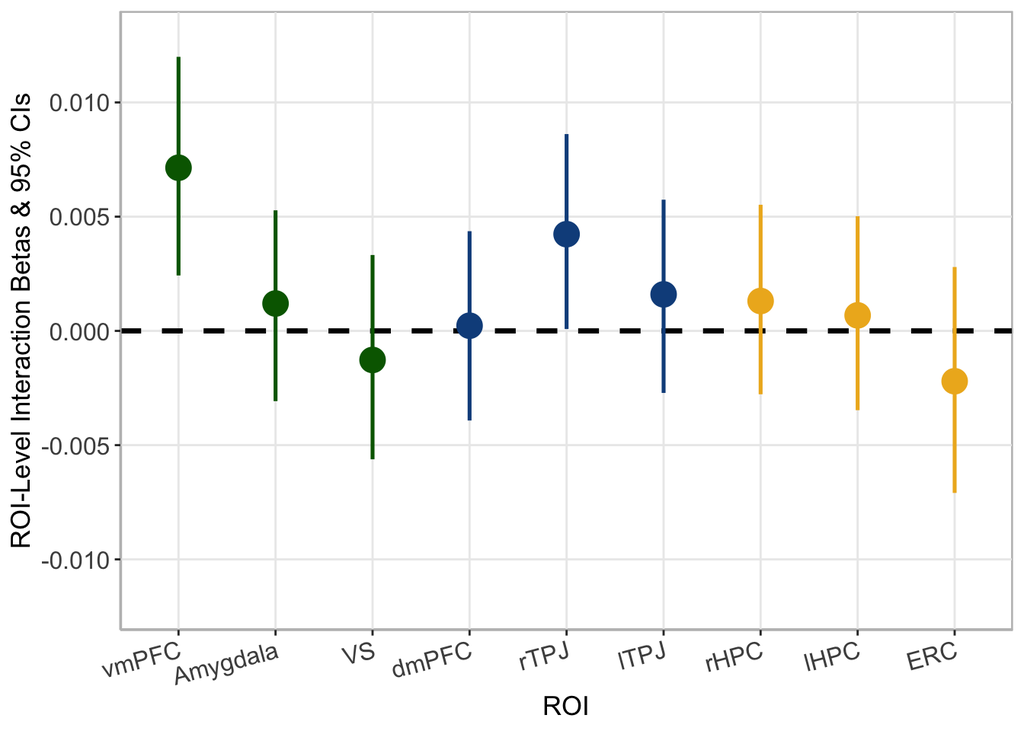

```r
# Load model results
load(sprintf("%s/Model Results/RSA_Model1_Controls.RData", path))

# Extract posterior draws
roi_draws <- m %>%
  spread_draws(b_Intercept, b_like_diff_cw, b_leader_diff_cw,
               `b_like_diff_cw:leader_diff_cw`,
               `r_brain_system:roi`[roi, term]) %>%
  mutate(beta = case_when(
    term == "Intercept" ~ b_Intercept + `r_brain_system:roi`,
    term == "like_diff_cw" ~ b_like_diff_cw + `r_brain_system:roi`,
    term == "leader_diff_cw" ~ b_leader_diff_cw + `r_brain_system:roi`,
    term == "like_diff_cw:leader_diff_cw" ~ `b_like_diff_cw:leader_diff_cw` + `r_brain_system:roi`)) %>%
  mutate(roi = dplyr::recode(roi,
                             "social_cognition_Saxe_dmPFC" = "dmPFC",
                             "valuation_HO_amygdala" = "Amygdala",
                             "relational_binding_r_HPC" = "rHPC",
                             "social_cognition_r_TPJ" = "rTPJ",
                             "valuation_Kable_VS" = "VS",
                             "relational_binding_ERC" = "ERC",
                             "relational_binding_l_HPC" = "lHPC",
                             "social_cognition_l_TPJ" = "lTPJ",
                             "valuation_vmPFC" = "vmPFC"),
         roi = factor(roi, levels = c("vmPFC", "Amygdala", "VS",
                                          "dmPFC", "rTPJ", "lTPJ",
                                          "rHPC", "lHPC", "ERC")),
         roi_type = ifelse(roi %in% c("vmPFC", "Amygdala", "VS"), "valuation",
                        ifelse(roi %in% c("dmPFC", "rTPJ", "lTPJ"), "social_cognition",
                               "relational_binding"))) %>%
  select(.draw, roi, roi_type, term, beta)

# Summarize estimates per ROI
b_df <- roi_draws %>%
  group_by(roi, roi_type, term) %>%
  summarise(beta_int = median(beta),
            sd = sd(beta),
            low_ci = quantile(beta, 0.025),
            upp_ci = quantile(beta, 0.975))

# Save beta sumamries in a .csv file
write.csv(b_df, (sprintf("%s/Data/RSA_Model1_Betas_Controls.csv", path)),
          row.names = F)

# Plot dyad-level betas' posterior mean and 95% credible interval
ggplot(data = b_df[b_df$term=="like_diff_cw:leader_diff_cw",],
       aes(x = roi,
           y = beta_int)) +
  geom_hline(yintercept = 0,
             linewidth = 1.2, linetype = 2) +
  geom_pointrange(aes(ymin = low_ci,
                      ymax = upp_ci, color = roi_type),
                  size = 1.2, linewidth = .9) +  # use for .html figure
  # geom_pointrange(aes(ymin = low_ci,
  #                     ymax = upp_ci, color = roi_type),
  #                 size = 2, linewidth = 2) + # use for .pdf figure
  scale_color_manual(values = c("goldenrod2", "dodgerblue4", "darkgreen")) +
  scale_y_continuous(expand = expansion(add = c(0.006, 0.002))) +
  labs(x = "ROI", y = "ROI-Level Interaction Betas & 95% CIs") +
  theme(axis.text.x = element_text(angle = 15, hjust = 1))
```

Check results.

```r
# Extract interaction posterior distribution
df_int <- b_df %>%
  filter(term == "like_diff_cw:leader_diff_cw") %>%
  ungroup() %>%   #
  mutate(across(where(is.numeric), ~ round(.x, 3)),
         CI_95 = paste0("[", low_ci, ", ", upp_ci, "]")) %>%
  select(-any_of(c("low_ci", "upp_ci", "roi_type", "term"))) %>%
  arrange(roi)

# Create table of results
b_df_table <- flextable(df_int) %>%
  set_header_labels(roi = "ROI",
    beta_int = "Beta Estimate",
    sd = "SE",
    CI_95 = "95% CI") %>%
  autofit() %>%
  theme_booktabs()

# Save to Word document
doc <- read_docx() %>%
  body_add_par("Table: RSA Results: Interaction Effects", style = "heading 2") %>%
  body_add_flextable(b_df_table)

print(doc, target = sprintf("%s/Tables/TableS10_RSA_Model1_Interaction_Betas_Controls.docx", path))

b_df_table
```

| ROI | Beta Estimate | SE | 95% CI |
| --- | --- | --- | --- |
| vmPFC | 0.007 | 0.002 | [0.002, 0.012] |
| Amygdala | 0.001 | 0.002 | [-0.003, 0.005] |
| VS | -0.001 | 0.002 | [-0.006, 0.003] |
| dmPFC | 0.000 | 0.002 | [-0.004, 0.004] |
| rTPJ | 0.004 | 0.002 | [0, 0.009] |
| lTPJ | 0.002 | 0.002 | [-0.003, 0.006] |
| rHPC | 0.001 | 0.002 | [-0.003, 0.006] |
| lHPC | 0.001 | 0.002 | [-0.003, 0.005] |
| ERC | -0.002 | 0.003 | [-0.007, 0.003] |

What percentage of the distribution is higher than zero for the vmPFC and rTPJ interaction effects?

```r
# Extract only the interaction posterior distributions.
roi_draws_int <- roi_draws %>%
    filter(term == "like_diff_cw:leader_diff_cw")

# vmPFC
round(length(which(roi_draws_int$beta[roi_draws_int$roi == "vmPFC"]>0))/4000*100,1)
```

```
## [1] 99.9
```

```r
# r TPJ
round(length(which(roi_draws_int$beta[roi_draws_int$roi == "rTPJ"]>0))/4000*100,1)
```

```
## [1] 97.8
```

Plot the **vmPFC interaction effect**. To understand what the interaction effect means, check how the relationship between difference in leadership status and neural dissimilarity in the vmPFC is moderated by difference in popularity status.

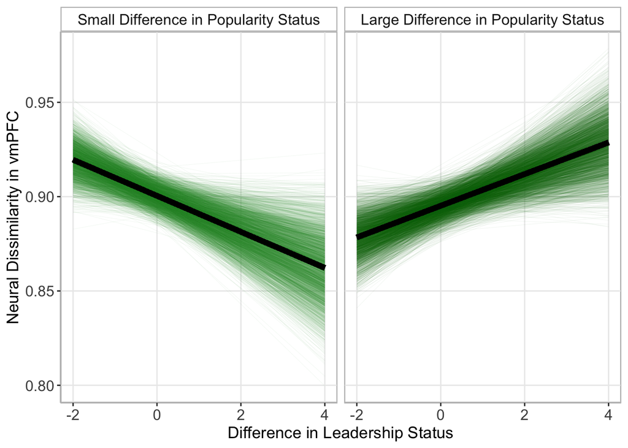

```r
# Extract all vmPFC-specific  posterior distributions
p <- roi_draws %>%
  filter(roi == "vmPFC")  %>%
  select(.draw, term, beta) %>%
  pivot_wider(names_from = term, values_from = beta)  %>%
  dplyr::rename(draw =.draw,
                intercept = Intercept,
                b_like_diff = like_diff_cw,
                b_leader_diff = leader_diff_cw,
                b_like_leader_int = `like_diff_cw:leader_diff_cw`)

# Calculate summary values
p <- p %>%
  dplyr::mutate(m_int = median(intercept),
         m_b_like_diff = median(b_like_diff),
         m_b_leader_diff = median(b_leader_diff),
         m_b_like_leader_int = median(b_like_leader_int))

# Sample 4000 random draws (decrease the number if fewer random draws wanted)
nr_random_draws <- 4000

# Calculate  +/-1.5SD*(Popularity Difference)
lw_1.5sd <- round(-1.5*sd(d$like_diff_cw, na.rm = T), 3)
up_1.5sd <- round(1.5*sd(d$like_diff_cw, na.rm = T), 3)

# Create a dataframe that includes predicted y values for like_diff = lw_1.5sd for the random draws
p_lw <- p[rep(seq_len(nrow(p)), each = 7), ] %>%
  mutate(seq = rep(-2:4, nr_random_draws),
         like_diff = lw_1.5sd,
         like_diff_label = "Small Difference in Popularity Status") %>%
  rowwise() %>%
  dplyr::mutate(y_draw = intercept + b_like_diff * like_diff + b_leader_diff * seq +
           b_like_leader_int * like_diff * seq,
         y_fe = m_int + m_b_like_diff * like_diff + m_b_leader_diff * seq +
           m_b_like_leader_int * like_diff * seq)

# Create a dataframe that includes predicted y values for like_diff = up_1.5sd for the random draws
p_up <- p[rep(seq_len(nrow(p)), each = 7), ] %>%
  mutate(seq = rep(-2:4, nr_random_draws),
         like_diff = up_1.5sd,
         like_diff_label = "Large Difference in Popularity Status") %>%
  rowwise() %>%
  dplyr::mutate(y_draw = intercept + b_like_diff * like_diff + b_leader_diff * seq +
           b_like_leader_int * like_diff * seq,
         y_fe = m_int + m_b_like_diff * like_diff + m_b_leader_diff * seq +
           m_b_like_leader_int * like_diff * seq)

# Merge files
p_all <- rbind(p_lw, p_up)

# Make the grouping variable a factor
p_all$like_diff_label <- factor(p_all$like_diff_label,
                                  levels = c("Small Difference in Popularity Status",
                                          "Large Difference in Popularity Status"))

# Plot results - separate plots for +/-1.5SD*(Popularity Difference)
ggplot(p_all, aes(x = seq, y_draw, group = draw)) +
  facet_wrap(~like_diff_label) +
  labs(y = "Neural Dissimilarity in vmPFC",
       x = "Difference in Leadership Status") +
  geom_line(aes(color = like_diff_label), alpha = .1, size = .1) +
  geom_line(aes(seq, y_fe), color = "black", size = 2) +
  scale_color_manual(values = c(" forestgreen", "darkgreen"))
```

```r
# Calculate individual slopes representing the relationship between
# leadership status difference and neural dissimilarity
# for each draw of the posterior distribution when like_diff = lw_1.5sd
p$b_leader_diff_lw <- (p$b_leader_diff + p$b_like_leader_int * lw_1.5sd)

# Extract the mean and 95% credible interval
b_leader_diff_lw <- round(quantile(p$b_leader_diff_lw, probs = c(0.025, .5, 0.975)),3)
b_leader_diff_lw
```

```
##   2.5%    50%  97.5%
## -0.017 -0.010 -0.002
```

```r
round(length(which(p$b_leader_diff_lw<0))/4000*100,1)
```

```
## [1] 99.6
```

```r
# Calculate individual slopes representing the relationship between
# leadership status difference and neural dissimilarity
# for each draw of the posterior distribution when like_diff = up_1.5sd
p$b_leader_diff_up <- (p$b_leader_diff + p$b_like_leader_int * up_1.5sd)

# Extract the mean and 95% credible interval
b_leader_diff_up <- round(quantile(p$b_leader_diff_up, probs = c(0.025, .5, 0.975)),3)
b_leader_diff_up
```

```
##  2.5%   50% 97.5%
## 0.002 0.008 0.015
```

```r
round(length(which(p$b_leader_diff_up>0))/4000*100,1)
```

```
## [1] 99.4
```

Plot the **rTPJ interaction effect**. To understand what the interaction effect means, check how the relationship between difference in leadership status and neural dissimilarity in the rTPJ is moderated by difference in popularity status.

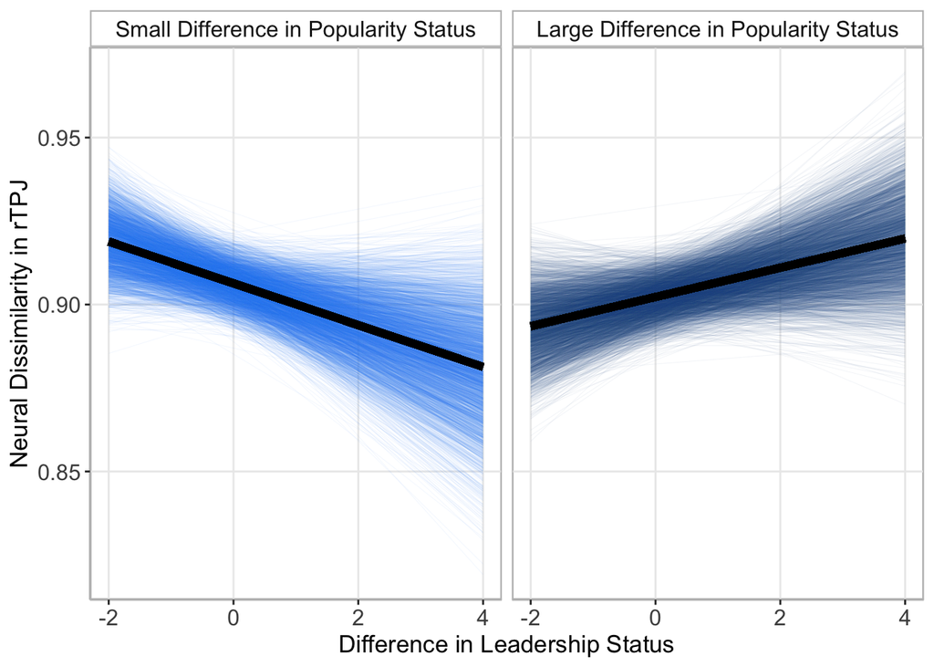

```r
# Extract all rTPJ-specific  posterior distributions
p <- roi_draws %>%
  filter(roi == "rTPJ")  %>%
  select(.draw, term, beta) %>%
  pivot_wider(names_from = term, values_from = beta)  %>%
  dplyr::rename(draw =.draw,
                intercept = Intercept,
                b_like_diff = like_diff_cw,
                b_leader_diff = leader_diff_cw,
                b_like_leader_int = `like_diff_cw:leader_diff_cw`)

# Calculate summary values
p <- p %>%
  dplyr::mutate(m_int = median(intercept),
         m_b_like_diff = median(b_like_diff),
         m_b_leader_diff = median(b_leader_diff),
         m_b_like_leader_int = median(b_like_leader_int))

# Create a dataframe that includes predicted y values for like_diff = lw_1.5sd for the random draws
p_lw <- p[rep(seq_len(nrow(p)), each = 7), ] %>%
  mutate(seq = rep(-2:4, nr_random_draws),
         like_diff = lw_1.5sd,
         like_diff_label = "Small Difference in Popularity Status") %>%
  rowwise() %>%
  dplyr::mutate(y_draw = intercept + b_like_diff * like_diff + b_leader_diff * seq +
           b_like_leader_int * like_diff * seq,
         y_fe = m_int + m_b_like_diff * like_diff + m_b_leader_diff * seq +
           m_b_like_leader_int * like_diff * seq)

# Create a dataframe that includes predicted y values for like_diff = up_1.5sd for the random draws
p_up <- p[rep(seq_len(nrow(p)), each = 7), ] %>%
  mutate(seq = rep(-2:4, nr_random_draws),
         like_diff = up_1.5sd,
         like_diff_label = "Large Difference in Popularity Status") %>%
  rowwise() %>%
  dplyr::mutate(y_draw = intercept + b_like_diff * like_diff + b_leader_diff * seq +
           b_like_leader_int * like_diff * seq,
         y_fe = m_int + m_b_like_diff * like_diff + m_b_leader_diff * seq +
           m_b_like_leader_int * like_diff * seq)

# Merge files
p_all <- rbind(p_lw, p_up)

# Make the grouping variable a factor
p_all$like_diff_label <- factor(p_all$like_diff_label,
                                  levels = c("Small Difference in Popularity Status",
                                          "Large Difference in Popularity Status"))

# Plot results - separate plots for both +/-1.5SD*(Popularity Difference)
ggplot(p_all, aes(x = seq, y_draw, group = draw)) +
  facet_wrap(~like_diff_label) +
  labs(y = "Neural Dissimilarity in rTPJ",
       x = "Difference in Leadership Status") +
  geom_line(aes(color = like_diff_label), alpha = .1, size = .1) +
  geom_line(aes(seq, y_fe), color = "black", size = 2) +
  scale_color_manual(values = c("dodgerblue2", "dodgerblue4"))
```

```r
# Calculate individual slopes representing the relationship between
# leadership status difference and neural dissimilarity
# for each draw of the posterior distribution when like_diff = lw_1.5sd
p$b_leader_diff_lw <- (p$b_leader_diff + p$b_like_leader_int * lw_1.5sd)

# Extract the mean and 95% credible interval
b_leader_diff_lw <- round(quantile(p$b_leader_diff_lw, probs = c(0.025, .5, 0.975)),3)
b_leader_diff_lw
```

```
##   2.5%    50%  97.5%
## -0.013 -0.006  0.001
```

```r
round(length(which(p$b_leader_diff_lw<0))/4000*100,1)
```

```
## [1] 96.4
```

```r
# Calculate individual slopes representing the relationship between
# leadership status difference and neural dissimilarity
# for each draw of the posterior distribution when like_diff = up_1.5sd
p$b_leader_diff_up <- (p$b_leader_diff + p$b_like_leader_int * up_1.5sd)

# Extract the mean and 95% credible interval
b_leader_diff_up <- round(quantile(p$b_leader_diff_up, probs = c(0.025, .5, 0.975)),3)
b_leader_diff_up
```

```
##   2.5%    50%  97.5%
## -0.002  0.004  0.011
```

```r
round(length(which(p$b_leader_diff_up>0))/4000*100,1)
```

```
## [1] 91.3
```

Obtain ROI-level varying betas for the **popularity status difference main effect**.

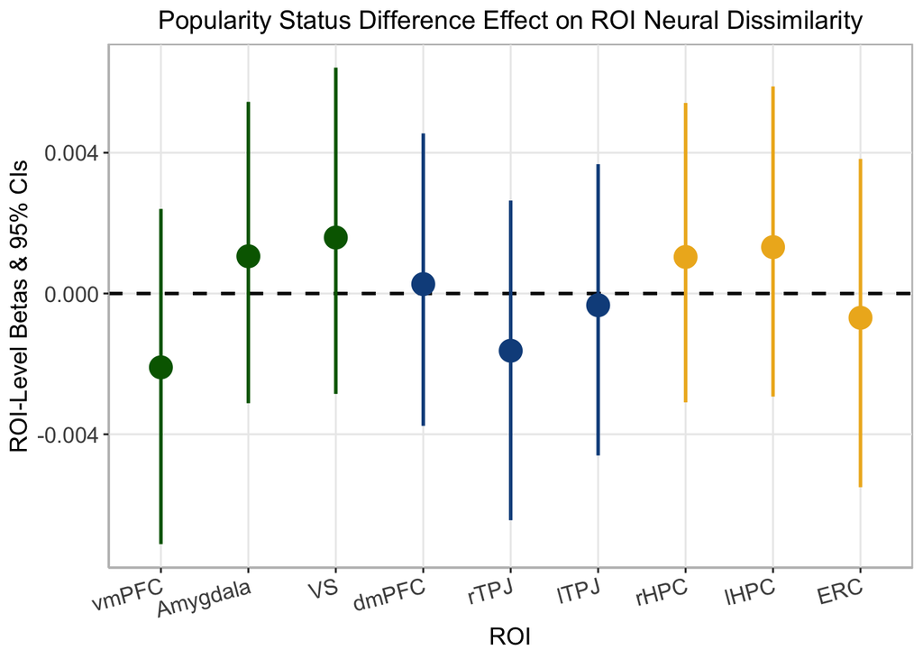

```r
# Save posterior draws of ROI-specific popularity status slope
roi_draws_like <- roi_draws %>%
  filter(term == "like_diff_cw")

# Summarize estimates per ROI
b_df <- roi_draws_like %>%
  group_by(roi, roi_type) %>%
  summarise(beta_like = median(beta),
            sd = sd(beta),
            low_ci = quantile(beta, 0.025),
            upp_ci = quantile(beta, 0.975))

# Plot dyad-level betas' posterior mean and 95% credible interval
ggplot(data = b_df,
       aes(x = roi,
           y = beta_like)) +
  geom_hline(yintercept = 0,
             linewidth = 0.9, linetype = 2) +
  geom_pointrange(aes(ymin = low_ci,
                      ymax = upp_ci, color = roi_type),
                  size = 1.2, linewidth = .9) +
  labs(x = "ROI", y = "ROI-Level Betas & 95% CIs",
       title = "Popularity Status Difference Effect on ROI Neural Dissimilarity") +
  scale_color_manual(values = c("goldenrod2", "dodgerblue4", "darkgreen")) +
  theme(axis.text.x = element_text(angle = 15, hjust = 1))
```

Check results.

```r
# Arrange data
b_df_table <- b_df %>%
  mutate(across(where(is.numeric), ~ round(.x, 3)),
         CI_95 = paste0("[", round(low_ci, 3), ", ", round(upp_ci, 3), "]")) %>%
  select(-c(low_ci, upp_ci, roi_type)) %>%
  arrange(roi)

# Create table of results
b_df_table <- flextable(b_df_table) %>%
  set_header_labels(roi = "ROI",
    beta_like = "Beta Estimate",
    sd = "SE",
    CI_95 = "95% CI") %>%
  autofit() %>%
  theme_booktabs()

# Save to Word document
doc <- read_docx() %>%
  body_add_par("Table: RSA Results: Popularity Status Difference Main Effect",
               style = "heading 2") %>%
  body_add_flextable(b_df_table)

print(doc, target = sprintf("%s/Tables/TableS6_RSA_Model1_Popularity_Betas_Controls.docx", path))

b_df_table
```

| ROI | Beta Estimate | SE | 95% CI |
| --- | --- | --- | --- |
| vmPFC | -0.002 | 0.002 | [-0.007, 0.002] |
| Amygdala | 0.001 | 0.002 | [-0.003, 0.005] |
| VS | 0.002 | 0.002 | [-0.003, 0.006] |
| dmPFC | 0.000 | 0.002 | [-0.004, 0.005] |
| rTPJ | -0.002 | 0.002 | [-0.006, 0.003] |
| lTPJ | 0.000 | 0.002 | [-0.005, 0.004] |
| rHPC | 0.001 | 0.002 | [-0.003, 0.005] |
| lHPC | 0.001 | 0.002 | [-0.003, 0.006] |
| ERC | -0.001 | 0.002 | [-0.006, 0.004] |

Obtain ROI-level varying betas for the **leadership status difference main effect**.

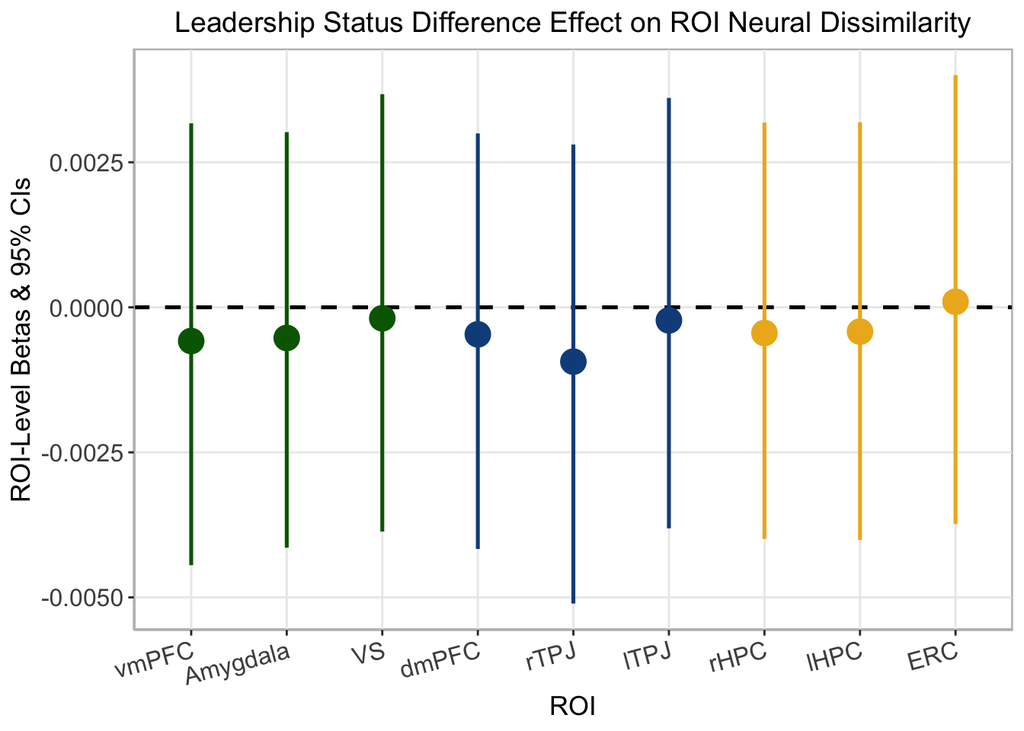

```r
# Save posterior draws of ROI-specific leadership status slope
roi_draws_leader <- roi_draws %>%
  filter(term == "leader_diff_cw")

# Summarize estimates per ROI
b_df <- roi_draws_leader %>%
  group_by(roi, roi_type) %>%
  summarise(beta_leader = median(beta),
            sd = sd(beta),
            low_ci = quantile(beta, 0.025),
            upp_ci = quantile(beta, 0.975))

# Plot dyad-level betas' posterior mean and 95% credible interval
ggplot(data = b_df,
       aes(x = roi,
           y = beta_leader)) +
  geom_hline(yintercept = 0,
             linewidth = 0.9, linetype = 2) +
  geom_pointrange(aes(ymin = low_ci,
                      ymax = upp_ci, color = roi_type),
                  size = 1.2, linewidth = .9) +
  labs(x = "ROI", y = "ROI-Level Betas & 95% CIs",
       title = "Leadership Status Difference Effect on ROI Neural Dissimilarity") +
  scale_color_manual(values = c("goldenrod2", "dodgerblue4", "darkgreen")) +
  theme(axis.text.x = element_text(angle = 15, hjust = 1))
```

Check results.

```r
# Arrange data
b_df_table <- b_df %>%
  mutate(across(where(is.numeric), ~ round(.x, 3)),
         CI_95 = paste0("[", round(low_ci, 3), ", ", round(upp_ci, 3), "]")) %>%
  select(-c(low_ci, upp_ci, roi_type)) %>%
  arrange(roi)

# Create table of results
b_df_table <- flextable(b_df_table) %>%
  set_header_labels(roi = "ROI",
    beta_leader = "Beta Estimate",
    sd = "SE",
    CI_95 = "95% CI") %>%
  autofit() %>%
  theme_booktabs()

# Save to Word document
doc <- read_docx() %>%
  body_add_par("Table: RSA Results: Leadership Status Difference Main Effect",
               style = "heading 2") %>%
  body_add_flextable(b_df_table)

print(doc, target = sprintf("%s/Tables/TableS8_RSA_Model1_Leadership_Betas_Controls.docx", path))

b_df_table
```

| ROI | Beta Estimate | SE | 95% CI |
| --- | --- | --- | --- |
| vmPFC | -0.001 | 0.002 | [-0.004, 0.003] |
| Amygdala | -0.001 | 0.002 | [-0.004, 0.003] |
| VS | 0.000 | 0.002 | [-0.004, 0.004] |
| dmPFC | 0.000 | 0.002 | [-0.004, 0.003] |
| rTPJ | -0.001 | 0.002 | [-0.005, 0.003] |
| lTPJ | 0.000 | 0.002 | [-0.004, 0.004] |
| rHPC | 0.000 | 0.002 | [-0.004, 0.003] |
| lHPC | 0.000 | 0.002 | [-0.004, 0.003] |
| ERC | 0.000 | 0.002 | [-0.004, 0.004] |

Check convergence (R-hat, bulk & tail ESS).

```r
summary(m)
```

```
##  Family: gaussian
##   Links: mu = identity; sigma = identity
## Formula: neural_dissimilarity ~ like_diff_cw * leader_diff_cw + like_avg_cw + leader_avg_cw + attractive_diff_cw + attractive_avg_cw + gender_diff_cw + college_year_diff_cw + educ_parents_diff_cw + income_num_diff_cw + pID_like_strength_in_cw + pID_leader_strength_in_cw + pID_mean_attractive_rati…
##    Data: d (Number of observations: 223820)
##   Draws: 4 chains, each with iter = 2000; warmup = 1000; thin = 1;
##          total post-warmup draws = 4000
##
## Multilevel Hyperparameters:
## ~brain_system:roi (Number of levels: 9)
##                                                 Estimate Est.Error l-95% CI
## sd(Intercept)                                       0.03      0.01     0.02
## sd(like_diff_cw)                                    0.00      0.00     0.00
## sd(leader_diff_cw)                                  0.00      0.00     0.00
## sd(like_diff_cw:leader_diff_cw)                     0.00      0.00     0.00
## cor(Intercept,like_diff_cw)                         0.50      0.36    -0.36
## cor(Intercept,leader_diff_cw)                       0.02      0.43    -0.76
## cor(like_diff_cw,leader_diff_cw)                   -0.02      0.44    -0.80
## cor(Intercept,like_diff_cw:leader_diff_cw)         -0.22      0.32    -0.78
## cor(like_diff_cw,like_diff_cw:leader_diff_cw)      -0.31      0.38    -0.89
## cor(leader_diff_cw,like_diff_cw:leader_diff_cw)    -0.16      0.43    -0.86
##                                                 u-95% CI Rhat Bulk_ESS Tail_ESS
## sd(Intercept)                                       0.06 1.01     1109     2007
## sd(like_diff_cw)                                    0.00 1.00     1805     1146
## sd(leader_diff_cw)                                  0.00 1.00     2623     2241
## sd(like_diff_cw:leader_diff_cw)                     0.01 1.00     1921     1731
## cor(Intercept,like_diff_cw)                         0.95 1.00     4245     2949
## cor(Intercept,leader_diff_cw)                       0.79 1.00     7341     2917
## cor(like_diff_cw,leader_diff_cw)                    0.78 1.00     5355     3243
## cor(Intercept,like_diff_cw:leader_diff_cw)          0.45 1.00     4615     3074
## cor(like_diff_cw,like_diff_cw:leader_diff_cw)       0.52 1.00     1927     2941
## cor(leader_diff_cw,like_diff_cw:leader_diff_cw)     0.69 1.00     2084     2816
##
## ~groupID:dyad_name (Number of levels: 2904)
##               Estimate Est.Error l-95% CI u-95% CI Rhat Bulk_ESS Tail_ESS
## sd(Intercept)     0.05      0.00     0.05     0.06 1.00     1476     2461
##
## ~groupID:pID (Number of levels: 95)
##               Estimate Est.Error l-95% CI u-95% CI Rhat Bulk_ESS Tail_ESS
## sd(Intercept)     0.03      0.00     0.03     0.04 1.00     1200     2054
##
```

[output cut: 42 more lines]

```
## pID_gender_cw                       1143     1533
## pID_college_year_cw                  869     1865
## pID_educ_parents_cw                 1029     1852
## pID_income_num_cw                   1105     1695
## like_diff_indepent_ratings_cw       4255     3212
## leader_diff_indepent_ratings_cw     4393     3212
## like_diff_cw:leader_diff_cw         3328     3070
##
## Further Distributional Parameters:
##       Estimate Est.Error l-95% CI u-95% CI Rhat Bulk_ESS Tail_ESS
## sigma     0.29      0.00     0.28     0.29 1.00     4554     2284
##
## Draws were sampled using sampling(NUTS). For each parameter, Bulk_ESS
## and Tail_ESS are effective sample size measures, and Rhat is the potential
## scale reduction factor on split chains (at convergence, Rhat = 1).
```

```r
draws <- as_draws_df(m)
summarise_draws(draws, rhat, "ess_bulk", "ess_tail") %>%
  filter(grepl("brain_system:roi", variable)) %>%
  mutate(across(where(is.numeric), ~ round(.x, 4)))
```

| variable | rhat | ess_bulk | ess_tail |
| --- | --- | --- | --- |
| sd_brain_system:roi__Intercept | 1.0066 | 1108.591 | 2007.365 |
| sd_brain_system:roi__like_diff_cw | 1.0036 | 1804.828 | 1146.306 |
| sd_brain_system:roi__leader_diff_cw | 1.0004 | 2623.381 | 2241.255 |
| sd_brain_system:roi__like_diff_cw:leader_diff_cw | 1.0001 | 1921.422 | 1731.055 |
| cor_brain_system:roi__Intercept__like_diff_cw | 1.0006 | 4244.529 | 2948.973 |
| cor_brain_system:roi__Intercept__leader_diff_cw | 1.0014 | 7341.097 | 2916.936 |
| cor_brain_system:roi__like_diff_cw__leader_diff_cw | 1.0001 | 5355.150 | 3242.729 |
| cor_brain_system:roi__Intercept__like_diff_cw:leader_diff_cw | 1.0003 | 4615.209 | 3073.765 |
| cor_brain_system:roi__like_diff_cw__like_diff_cw:leader_diff_cw | 1.0027 | 1927.492 | 2941.192 |
| cor_brain_system:roi__leader_diff_cw__like_diff_cw:leader_diff_cw | 1.0003 | 2083.890 | 2816.323 |

[output cut: 36 more lines]

# 2 Model 2 (Popularity Status Differences Main Effect)

Run multilevel regression model 2: Neural Dissimilarity ~ Popularity Status Differences + Control Variables

```r
# options(mc.cores = parallel::detectCores())
# m2 <- brm(neural_dissimilarity ~ like_diff_cw + like_avg_cw +
#            attractive_diff_cw + attractive_avg_cw +
#            gender_diff_cw + college_year_diff_cw +
#            educ_parents_diff_cw + income_num_diff_cw +
#            pID_like_strength_in_cw + pID_mean_attractive_rating_cw +
#            pID_gender_cw + pID_college_year_cw + pID_educ_parents_cw +
#            pID_income_num_cw + like_diff_indepent_ratings_cw +
#            (1 | groupID:pID) +
#            (1 | groupID:dyad_name) +
#            (1 | mm(face_1, face_2)) +
#            (like_diff_cw | brain_system:roi),
#          data = d,
#          control = list(adapt_delta = 0.99),
#          seed = 123)
# save(m2, file = sprintf("%s/Model Results/RSA_Model2_Controls.RData", path))
```

Obtain ROI-level varying betas for the **popularity status difference main effect**.

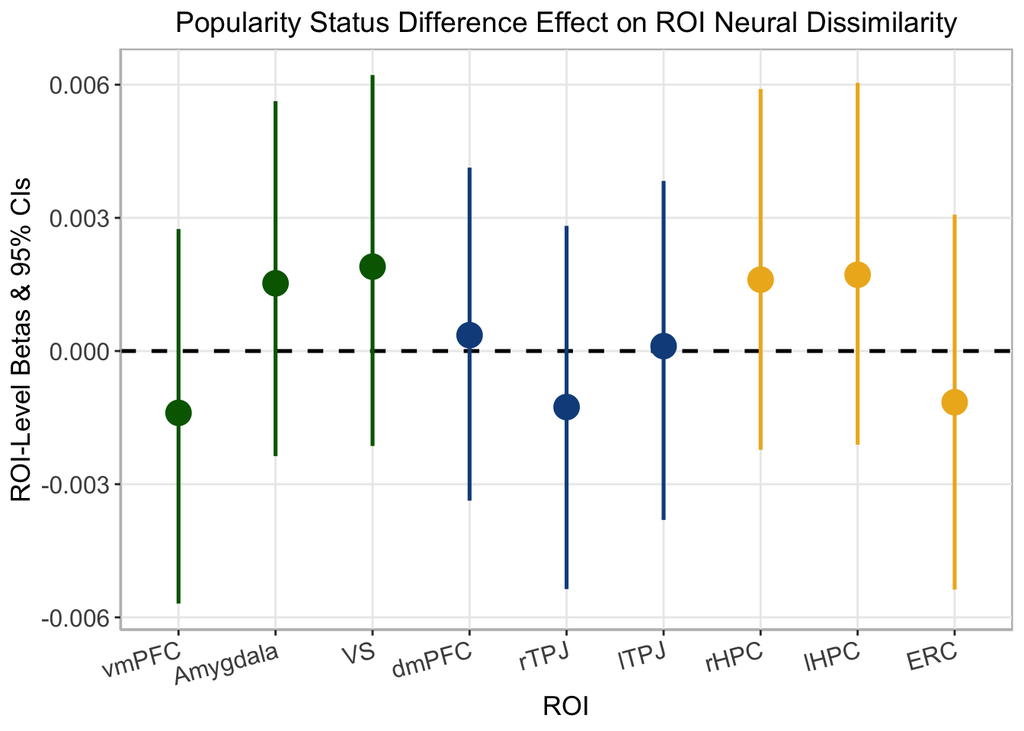

```r
# Load model results
load(sprintf("%s/Model Results/RSA_Model2_Controls.RData", path))

# Extract posterior draws
roi_draws <- m2 %>%
  spread_draws(b_like_diff_cw,
               `r_brain_system:roi`[roi, term]) %>%
  filter(term == "like_diff_cw") %>%
  mutate(beta = b_like_diff_cw + `r_brain_system:roi`) %>%
  mutate(roi = dplyr::recode(roi,
                             "social_cognition_Saxe_dmPFC" = "dmPFC",
                             "valuation_HO_amygdala" = "Amygdala",
                             "relational_binding_r_HPC" = "rHPC",
                             "social_cognition_r_TPJ" = "rTPJ",
                             "valuation_Kable_VS" = "VS",
                             "relational_binding_ERC" = "ERC",
                             "relational_binding_l_HPC" = "lHPC",
                             "social_cognition_l_TPJ" = "lTPJ",
                             "valuation_vmPFC" = "vmPFC"),
         roi = factor(roi, levels = c("vmPFC", "Amygdala", "VS",
                                          "dmPFC", "rTPJ", "lTPJ",
                                          "rHPC", "lHPC", "ERC")),
         roi_type = ifelse(roi %in% c("vmPFC", "Amygdala", "VS"), "valuation",
                        ifelse(roi %in% c("dmPFC", "rTPJ", "lTPJ"), "social_cognition",
                               "relational_binding"))) %>%
  select(.draw, roi, roi_type, beta)

# Summarize estimates per ROI
b_df <- roi_draws %>%
  group_by(roi, roi_type, term) %>%
  summarise(beta_like = median(beta),
            sd = sd(beta),
            low_ci = quantile(beta, 0.025),
            upp_ci = quantile(beta, 0.975))

# Plot dyad-level betas' posterior mean and 95% credible interval
ggplot(data = b_df,
       aes(x = roi,
           y = beta_like)) +
  geom_hline(yintercept = 0,
             linewidth = 0.9, linetype = 2) +
  geom_pointrange(aes(ymin = low_ci,
                      ymax = upp_ci, color = roi_type),
                  size = 1.2, linewidth = .9) +
  labs(x = "ROI", y = "ROI-Level Betas & 95% CIs",
       title = "Popularity Status Difference Effect on ROI Neural Dissimilarity") +
  scale_color_manual(values = c("goldenrod2", "dodgerblue4", "darkgreen")) +
  theme(axis.text.x = element_text(angle = 15, hjust = 1))
```

Check results.

```r
# Arrange data
b_df_table <- b_df %>%
  ungroup() %>%
  mutate(across(where(is.numeric), ~ round(.x, 3)),
         CI_95 = paste0("[", round(low_ci, 3), ", ", round(upp_ci, 3), "]")) %>%
  select(-any_of(c("low_ci", "upp_ci", "roi_type", "term"))) %>%
  arrange(roi)

# Create table of results
b_df_table <- flextable(b_df_table) %>%
  set_header_labels(roi = "ROI",
    beta_like = "Beta Estimate",
    sd = "SE",
    CI_95 = "95% CI") %>%
  autofit() %>%
  theme_booktabs()

# Save to Word document
doc <- read_docx() %>%
  body_add_par("Table: RSA Results: Popularity Status Difference Main Effect",
               style = "heading 2") %>%
  body_add_flextable(b_df_table)

print(doc, target = sprintf("%s/Tables/TableS7_RSA_Model2_Popularity_Betas_Controls.docx", path))

b_df_table
```

| ROI | Beta Estimate | SE | 95% CI |
| --- | --- | --- | --- |
| vmPFC | -0.001 | 0.002 | [-0.006, 0.003] |
| Amygdala | 0.002 | 0.002 | [-0.002, 0.006] |
| VS | 0.002 | 0.002 | [-0.002, 0.006] |
| dmPFC | 0.000 | 0.002 | [-0.003, 0.004] |
| rTPJ | -0.001 | 0.002 | [-0.005, 0.003] |
| lTPJ | 0.000 | 0.002 | [-0.004, 0.004] |
| rHPC | 0.002 | 0.002 | [-0.002, 0.006] |
| lHPC | 0.002 | 0.002 | [-0.002, 0.006] |
| ERC | -0.001 | 0.002 | [-0.005, 0.003] |

Check convergence (R-hat, bulk & tail ESS).

```r
summary(m2)
```

```
##  Family: gaussian
##   Links: mu = identity; sigma = identity
## Formula: neural_dissimilarity ~ like_diff_cw + like_avg_cw + attractive_diff_cw + attractive_avg_cw + gender_diff_cw + college_year_diff_cw + educ_parents_diff_cw + income_num_diff_cw + pID_like_strength_in_cw + pID_mean_attractive_rating_cw + pID_gender_cw + pID_college_year_cw + pID_educ_parent…
##    Data: d (Number of observations: 223820)
##   Draws: 4 chains, each with iter = 2000; warmup = 1000; thin = 1;
##          total post-warmup draws = 4000
##
## Multilevel Hyperparameters:
## ~brain_system:roi (Number of levels: 9)
##                             Estimate Est.Error l-95% CI u-95% CI Rhat Bulk_ESS
## sd(Intercept)                   0.03      0.01     0.02     0.05 1.01      753
## sd(like_diff_cw)                0.00      0.00     0.00     0.00 1.00     1621
## cor(Intercept,like_diff_cw)     0.68      0.36    -0.40     1.00 1.00     3151
##                             Tail_ESS
## sd(Intercept)                   1974
## sd(like_diff_cw)                1205
## cor(Intercept,like_diff_cw)     2365
##
## ~groupID:dyad_name (Number of levels: 2904)
##               Estimate Est.Error l-95% CI u-95% CI Rhat Bulk_ESS Tail_ESS
## sd(Intercept)     0.05      0.00     0.05     0.06 1.00     1342     2336
##
## ~groupID:pID (Number of levels: 95)
##               Estimate Est.Error l-95% CI u-95% CI Rhat Bulk_ESS Tail_ESS
## sd(Intercept)     0.03      0.00     0.03     0.04 1.00     1031     1855
##
## ~mmface_1face_2 (Number of levels: 231)
##               Estimate Est.Error l-95% CI u-95% CI Rhat Bulk_ESS Tail_ESS
## sd(Intercept)     0.03      0.00     0.03     0.04 1.00      907     1813
##
## Regression Coefficients:
##                               Estimate Est.Error l-95% CI u-95% CI Rhat
## Intercept                         0.93      0.01     0.91     0.96 1.00
## like_diff_cw                      0.00      0.00    -0.00     0.00 1.00
## like_avg_cw                      -0.01      0.00    -0.01    -0.00 1.00
## attractive_diff_cw               -0.00      0.00    -0.00     0.00 1.00
## attractive_avg_cw                -0.00      0.00    -0.01     0.00 1.00
## gender_diff_cw                    0.00      0.00    -0.00     0.00 1.00
## college_year_diff_cw              0.00      0.00    -0.00     0.00 1.00
## educ_parents_diff_cw             -0.00      0.00    -0.00     0.00 1.00
```

[output cut: 18 more lines]

```
## pID_like_strength_in_cw            936     1660
## pID_mean_attractive_rating_cw     1002     1512
## pID_gender_cw                      865     1270
## pID_college_year_cw                948     1617
## pID_educ_parents_cw                810     1579
## pID_income_num_cw                  756     1590
## like_diff_indepent_ratings_cw     3976     3201
##
## Further Distributional Parameters:
##       Estimate Est.Error l-95% CI u-95% CI Rhat Bulk_ESS Tail_ESS
## sigma     0.29      0.00     0.28     0.29 1.00     4177     2178
##
## Draws were sampled using sampling(NUTS). For each parameter, Bulk_ESS
## and Tail_ESS are effective sample size measures, and Rhat is the potential
## scale reduction factor on split chains (at convergence, Rhat = 1).
```

```r
draws2 <- as_draws_df(m2)
summarise_draws(draws2, rhat, "ess_bulk", "ess_tail")%>%
  filter(grepl("brain_system:roi", variable)) %>%
  mutate(across(where(is.numeric), ~ round(.x, 4)))
```

| variable | rhat | ess_bulk | ess_tail |
| --- | --- | --- | --- |
| sd_brain_system:roi__Intercept | 1.0144 | 753.1987 | 1973.652 |
| sd_brain_system:roi__like_diff_cw | 1.0007 | 1620.6263 | 1205.142 |
| cor_brain_system:roi__Intercept__like_diff_cw | 1.0001 | 3150.8848 | 2365.175 |
| r_brain_system:roi[relational_binding_ERC,Intercept] | 1.0033 | 903.2319 | 1282.902 |
| r_brain_system:roi[relational_binding_l_HPC,Intercept] | 1.0033 | 901.7755 | 1261.151 |
| r_brain_system:roi[relational_binding_r_HPC,Intercept] | 1.0035 | 895.5976 | 1066.871 |
| r_brain_system:roi[social_cognition_l_TPJ,Intercept] | 1.0032 | 892.4334 | 1218.513 |
| r_brain_system:roi[social_cognition_r_TPJ,Intercept] | 1.0034 | 884.8934 | 1176.145 |
| r_brain_system:roi[social_cognition_Saxe_dmPFC,Intercept] | 1.0030 | 891.0488 | 1146.701 |
| r_brain_system:roi[valuation_HO_amygdala,Intercept] | 1.0032 | 885.9211 | 1312.824 |

[output cut: 11 more lines]

# 3 Model 3 (Leadership Status Differences Main Effect)

Run multilevel regression model 3: Neural Dissimilarity ~ Leadership Status Differences + Control Variables

```r
# options(mc.cores = parallel::detectCores())
# m3 <- brm(neural_dissimilarity ~ leader_diff_cw + leader_avg_cw +
#            attractive_diff_cw + attractive_avg_cw +
#            gender_diff_cw + college_year_diff_cw +
#            educ_parents_diff_cw + income_num_diff_cw +
#            pID_leader_strength_in_cw + pID_mean_attractive_rating_cw +
#            pID_gender_cw + pID_college_year_cw + pID_educ_parents_cw +
#            pID_income_num_cw + leader_diff_indepent_ratings_cw +
#            (1 | groupID:pID) +
#            (1 | groupID:dyad_name) +
#            (1 | mm(face_1, face_2)) +
#            (leader_diff_cw | brain_system:roi),
#          data = d,
#          control = list(adapt_delta = 0.99),
#          seed = 123)
# save(m3, file = sprintf("%s/Model Results/RSA_Model3_Controls.RData", path))
```

Obtain ROI-level varying betas for the **leadership status difference main effect**.

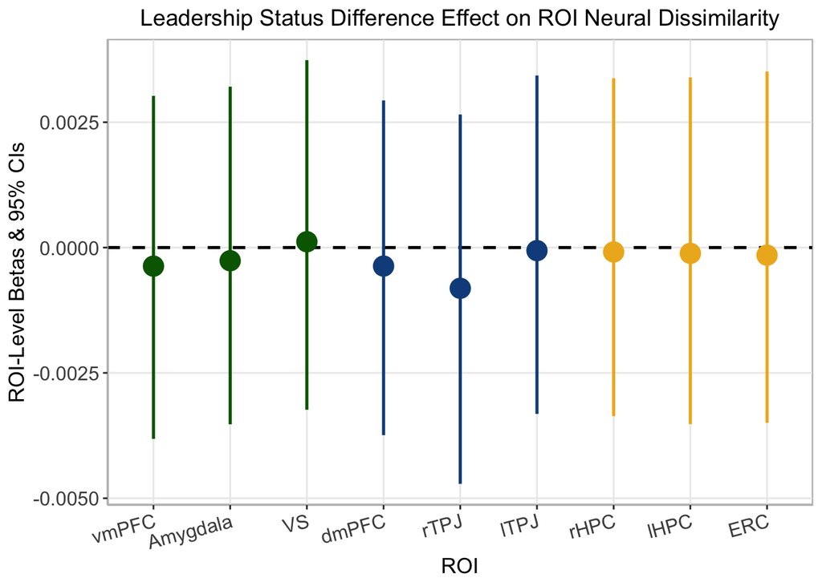

```r
# Load model results
load(sprintf("%s/Model Results/RSA_Model3_Controls.RData", path))

# Extract posterior draws
roi_draws <- m3 %>%
  spread_draws(b_leader_diff_cw,
               `r_brain_system:roi`[roi, term]) %>%
  filter(term == "leader_diff_cw") %>%
  mutate(beta = b_leader_diff_cw + `r_brain_system:roi`) %>%
  mutate(roi = dplyr::recode(roi,
                             "social_cognition_Saxe_dmPFC" = "dmPFC",
                             "valuation_HO_amygdala" = "Amygdala",
                             "relational_binding_r_HPC" = "rHPC",
                             "social_cognition_r_TPJ" = "rTPJ",
                             "valuation_Kable_VS" = "VS",
                             "relational_binding_ERC" = "ERC",
                             "relational_binding_l_HPC" = "lHPC",
                             "social_cognition_l_TPJ" = "lTPJ",
                             "valuation_vmPFC" = "vmPFC"),
         roi = factor(roi, levels = c("vmPFC", "Amygdala", "VS",
                                          "dmPFC", "rTPJ", "lTPJ",
                                          "rHPC", "lHPC", "ERC")),
         roi_type = ifelse(roi %in% c("vmPFC", "Amygdala", "VS"), "valuation",
                        ifelse(roi %in% c("dmPFC", "rTPJ", "lTPJ"), "social_cognition",
                               "relational_binding"))) %>%
  select(.draw, roi, roi_type, beta)

# Summarize estimates per ROI
b_df <- roi_draws %>%
  group_by(roi, roi_type, term) %>%
  summarise(beta_leader = median(beta),
            sd = sd(beta),
            low_ci = quantile(beta, 0.025),
            upp_ci = quantile(beta, 0.975))

# Plot dyad-level betas' posterior mean and 95% credible interval
ggplot(data = b_df,
       aes(x = roi,
           y = beta_leader)) +
  geom_hline(yintercept = 0,
             linewidth = 0.9, linetype = 2) +
  geom_pointrange(aes(ymin = low_ci,
                      ymax = upp_ci, color = roi_type),
                  size = 1.2, linewidth = .9) +
  labs(x = "ROI", y = "ROI-Level Betas & 95% CIs",
       title = "Leadership Status Difference Effect on ROI Neural Dissimilarity") +
  scale_color_manual(values = c("goldenrod2", "dodgerblue4", "darkgreen")) +
  theme(axis.text.x = element_text(angle = 15, hjust = 1))
```

Check results.

```r
# Arrange data
b_df_table <- b_df %>%
  ungroup() %>%
  mutate(across(where(is.numeric), ~ round(.x, 3)),
         CI_95 = paste0("[", round(low_ci, 3), ", ", round(upp_ci, 3), "]")) %>%
  select(-any_of(c("low_ci", "upp_ci", "roi_type", "term"))) %>%
  arrange(roi)

# Create table of results
b_df_table <- flextable(b_df_table) %>%
  set_header_labels(roi = "ROI",
    beta_leader = "Beta Estimate",
    sd = "SE",
    CI_95 = "95% CI") %>%
  autofit() %>%
  theme_booktabs()

# Save to Word document
doc <- read_docx() %>%
  body_add_par("Table: RSA Results: Leadership Status Difference Main Effect",
               style = "heading 2") %>%
  body_add_flextable(b_df_table)

print(doc, target = sprintf("%s/Tables/TableS9_RSA_Model3_Leadership_Betas_Controls.docx", path))

b_df_table
```

| ROI | Beta Estimate | SE | 95% CI |
| --- | --- | --- | --- |
| vmPFC | 0.000 | 0.002 | [-0.004, 0.003] |
| Amygdala | 0.000 | 0.002 | [-0.004, 0.003] |
| VS | 0.000 | 0.002 | [-0.003, 0.004] |
| dmPFC | 0.000 | 0.002 | [-0.004, 0.003] |
| rTPJ | -0.001 | 0.002 | [-0.005, 0.003] |
| lTPJ | 0.000 | 0.002 | [-0.003, 0.003] |
| rHPC | 0.000 | 0.002 | [-0.003, 0.003] |
| lHPC | 0.000 | 0.002 | [-0.004, 0.003] |
| ERC | 0.000 | 0.002 | [-0.003, 0.004] |

Check convergence (R-hat, bulk & tail ESS).

```r
summary(m3)
```

```
##  Family: gaussian
##   Links: mu = identity; sigma = identity
## Formula: neural_dissimilarity ~ leader_diff_cw + leader_avg_cw + attractive_diff_cw + attractive_avg_cw + gender_diff_cw + college_year_diff_cw + educ_parents_diff_cw + income_num_diff_cw + pID_leader_strength_in_cw + pID_mean_attractive_rating_cw + pID_gender_cw + pID_college_year_cw + pID_educ_…
##    Data: d (Number of observations: 223820)
##   Draws: 4 chains, each with iter = 2000; warmup = 1000; thin = 1;
##          total post-warmup draws = 4000
##
## Multilevel Hyperparameters:
## ~brain_system:roi (Number of levels: 9)
##                               Estimate Est.Error l-95% CI u-95% CI Rhat
## sd(Intercept)                     0.03      0.01     0.02     0.06 1.00
## sd(leader_diff_cw)                0.00      0.00     0.00     0.00 1.00
## cor(Intercept,leader_diff_cw)     0.16      0.54    -0.89     0.96 1.00
##                               Bulk_ESS Tail_ESS
## sd(Intercept)                      960     1573
## sd(leader_diff_cw)                2356     1919
## cor(Intercept,leader_diff_cw)     6355     2653
##
## ~groupID:dyad_name (Number of levels: 2904)
##               Estimate Est.Error l-95% CI u-95% CI Rhat Bulk_ESS Tail_ESS
## sd(Intercept)     0.05      0.00     0.05     0.06 1.00     1351     2273
##
## ~groupID:pID (Number of levels: 95)
##               Estimate Est.Error l-95% CI u-95% CI Rhat Bulk_ESS Tail_ESS
## sd(Intercept)     0.03      0.00     0.03     0.04 1.00     1136     1858
##
## ~mmface_1face_2 (Number of levels: 231)
##               Estimate Est.Error l-95% CI u-95% CI Rhat Bulk_ESS Tail_ESS
## sd(Intercept)     0.03      0.00     0.03     0.04 1.01      797     1803
##
## Regression Coefficients:
##                                 Estimate Est.Error l-95% CI u-95% CI Rhat
## Intercept                           0.93      0.01     0.91     0.96 1.00
## leader_diff_cw                     -0.00      0.00    -0.00     0.00 1.00
## leader_avg_cw                      -0.00      0.00    -0.01     0.00 1.00
## attractive_diff_cw                 -0.00      0.00    -0.00     0.00 1.00
## attractive_avg_cw                  -0.00      0.00    -0.01     0.00 1.00
## gender_diff_cw                      0.00      0.00    -0.00     0.00 1.00
## college_year_diff_cw                0.00      0.00    -0.00     0.00 1.00
## educ_parents_diff_cw               -0.00      0.00    -0.00     0.00 1.00
```

[output cut: 18 more lines]

```
## pID_leader_strength_in_cw            733     1399
## pID_mean_attractive_rating_cw        681     1260
## pID_gender_cw                        712     1409
## pID_college_year_cw                  871     1548
## pID_educ_parents_cw                  745     1287
## pID_income_num_cw                    660     1323
## leader_diff_indepent_ratings_cw     4246     3068
##
## Further Distributional Parameters:
##       Estimate Est.Error l-95% CI u-95% CI Rhat Bulk_ESS Tail_ESS
## sigma     0.29      0.00     0.28     0.29 1.00     3690     2476
##
## Draws were sampled using sampling(NUTS). For each parameter, Bulk_ESS
## and Tail_ESS are effective sample size measures, and Rhat is the potential
## scale reduction factor on split chains (at convergence, Rhat = 1).
```

```r
draws3 <- as_draws_df(m3)
summarise_draws(draws3, rhat, "ess_bulk", "ess_tail")%>%
  filter(grepl("brain_system:roi", variable)) %>%
  mutate(across(where(is.numeric), ~ round(.x, 4)))
```

| variable | rhat | ess_bulk | ess_tail |
| --- | --- | --- | --- |
| sd_brain_system:roi__Intercept | 1.0031 | 960.2387 | 1572.784 |
| sd_brain_system:roi__leader_diff_cw | 0.9999 | 2355.8452 | 1919.021 |
| cor_brain_system:roi__Intercept__leader_diff_cw | 1.0019 | 6355.1489 | 2652.610 |
| r_brain_system:roi[relational_binding_ERC,Intercept] | 1.0023 | 819.9901 | 1242.618 |
| r_brain_system:roi[relational_binding_l_HPC,Intercept] | 1.0021 | 812.6667 | 1283.934 |
| r_brain_system:roi[relational_binding_r_HPC,Intercept] | 1.0021 | 805.2349 | 1250.997 |
| r_brain_system:roi[social_cognition_l_TPJ,Intercept] | 1.0019 | 814.1254 | 1264.899 |
| r_brain_system:roi[social_cognition_r_TPJ,Intercept] | 1.0022 | 807.3228 | 1281.678 |
| r_brain_system:roi[social_cognition_Saxe_dmPFC,Intercept] | 1.0020 | 807.6719 | 1253.437 |
| r_brain_system:roi[valuation_HO_amygdala,Intercept] | 1.0018 | 808.1919 | 1196.350 |

[output cut: 11 more lines]